# Tarea_1

Juan_Urbina

2025-06-06

# Parte 1

Escriba el código de R necesario para resolver los siguientes incisos trate de usar la menor cantidad de líneas posible.

1. ¿Cómo generaría un arreglo aleatorio de 250 elementos con los colores primarios?

```r
ejer_1 <- sample(c("rojo", "azul", "amarillo"), 250, replace = TRUE)
ejer_1
```

```
##   [1] "rojo"     "rojo"     "amarillo" "rojo"     "azul"     "azul"
##   [7] "azul"     "azul"     "rojo"     "azul"     "azul"     "azul"
##  [13] "amarillo" "rojo"     "amarillo" "rojo"     "rojo"     "amarillo"
##  [19] "amarillo" "azul"     "rojo"     "rojo"     "azul"     "amarillo"
##  [25] "amarillo" "rojo"     "amarillo" "amarillo" "rojo"     "rojo"
##  [31] "azul"     "azul"     "amarillo" "rojo"     "azul"     "amarillo"
##  [37] "rojo"     "rojo"     "azul"     "rojo"     "rojo"     "amarillo"
##  [43] "azul"     "rojo"     "azul"     "azul"     "rojo"     "azul"
##  [49] "rojo"     "rojo"     "amarillo" "rojo"     "amarillo" "amarillo"
##  [55] "amarillo" "amarillo" "rojo"     "amarillo" "rojo"     "rojo"
##  [61] "azul"     "rojo"     "rojo"     "amarillo" "rojo"     "rojo"
##  [67] "rojo"     "rojo"     "rojo"     "rojo"     "azul"     "rojo"
##  [73] "rojo"     "rojo"     "azul"     "rojo"     "azul"     "azul"
##  [79] "amarillo" "azul"     "azul"     "azul"     "amarillo" "amarillo"
##  [85] "amarillo" "azul"     "azul"     "rojo"     "amarillo" "rojo"
```

[output cut: 27 more lines]

2. Dado un arreglo de 120000 elementos de números enteros entre 40 y 70, ¿Cómo haría para obtener la desviación estándar de aquellos números que son mayores a 55 y menores a 64?

```r
ejer_2 <- sd(sample(40:70, 120000, TRUE)[sample(40:70, 120000, TRUE) > 55 & sample(40:70, 120000, TRUE) < 64])
ejer_2
```

```
## [1] 8.961594
```

3. Sabemos que para sumar vectores estos deben tener la misma longitud. Sin embargo, R trabaja de manera distinta. Defina los vectores x = (1, 2, 3, 4, 5, 6), y = (7, 8), z = (9, 10, 11, 12).
1. Calcula:
   1. x + x
   2. x + y.
   3. Responda ¿Qué ha hecho R?

```r
x <- 1:6
y <- 7:8; z <- 9:12

# Parte (i)
x + x
```

```
## [1]  2  4  6  8 10 12
```

```r
# Parte (ii)
x + y
```

```
## [1]  8 10 10 12 12 14
```

```r
# Parte(iii)
## R recicla los valores de 'y' para completar la longitud de 'x'
```

4. Si b <- list(a=1:10, c=“Hola”, d=“XX”), escriba una expresión en R que devuelva todos los elementos de la lista excepto los elementos 2,4,6,7,8 del vector a.

```r
b <- list(a=1:10, c="Hola", d="XX")

b$a[!1:10 %in% c(2,4,6,7,8)]
```

```
## [1]  1  3  5  9 10
```

5. Suponga que se almacena en una variable un arreglo con todos los números de carnet de los estudiantes de la Escuela de Ciencias y Sistemas en forma de string, los carnets tienen al inicio cuatro caracteres que identifican el año en el que la persona entró a la universidad, por ejemplo: 201900452 hacer referencia a una persona que ingreso en el año 2019, 200600987 hace referencia a una persona que ingreso que el año 2006.
1. ¿Cómo haría para contar la cantidad de alumnos por año?

```r
carnets <- c("201900452", "201800321", "201900987", "200600123", "200600987",
             "201700111", "201800222", "201900333", "202000555", "202000666")

table(substr(carnets, 1, 4))
```

```
##
## 2006 2017 2018 2019 2020
##    2    1    2    3    2
```

6. Dada la variable string <- “Hola Mundo”, escriba una instrucción en R que devuelva la siguiente salida: [[1]] [1] “Hola” [[2]] [1] “Mundo”.

```r
string <- strsplit("Hola Mundo", " ")

string
```

```
## [[1]]
## [1] "Hola"  "Mundo"
```

```r
string[[1]][1]
```

```
## [1] "Hola"
```

```r
string[[1]][2]
```

```
## [1] "Mundo"
```

7. Utilizando el dataset flights de la librería nycflights23 (recordando: dataset<- flights), realizar lo siguiente:
1. Mostrar una gráfica de barras de manera decreciente con la cantidad de vuelo por aerolínea (columna “carrier”)
2. Mostrar una gráfica de líneas de cantidad de vuelos por mes (columna “month”).

```r
library(nycflights13)
library(dplyr)
```

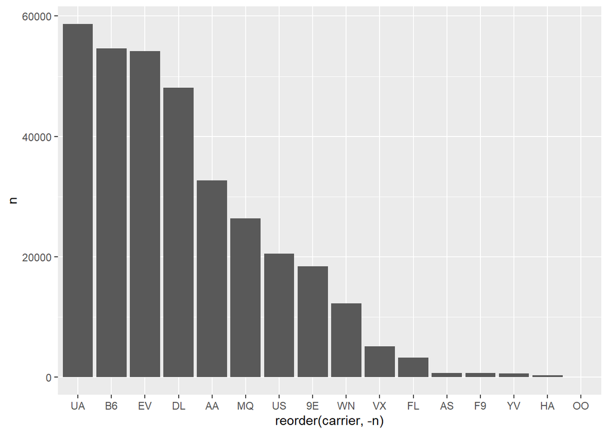

```r
library(ggplot2)

# 7.a
flights %>% count(carrier, sort=TRUE) %>%
  ggplot(aes(x=reorder(carrier, -n), y=n)) + geom_bar(stat="identity")
```

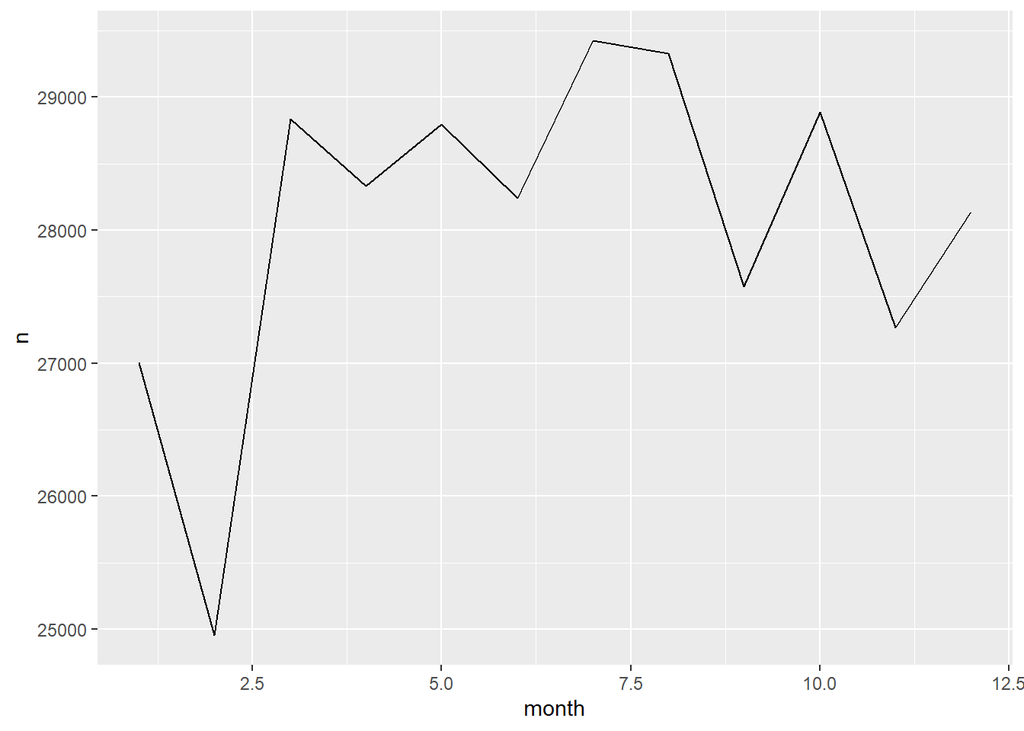

```r
# 7.b
flights %>% count(month) %>%
  ggplot(aes(x=month, y=n)) + geom_line()
```

# Parte 2

## Ejercicio 1: Lanzamiento de dos dados

Lanza dos dados justos. Define el espacio muestral y calcula las siguientes probabilidades: A. Que la suma sea 7. B. Que ambos dados muestren el mismo número. C. Que la suma sea 7 o los dados muestren el mismo número.

```r
muestral <- expand.grid(d1 = 1:6, d2 = 1:6)
A <- with(muestral, d1 + d2 == 7)
B <- with(muestral, d1 == d2)
C <- A | B
c(P_A = mean(A), P_B = mean(B), P_C = mean(C))
```

```
##       P_A       P_B       P_C
## 0.1666667 0.1666667 0.3333333
```

## Ejercicio 2: Lanzamiento de tres monedas

Lanza tres monedas justas. Simula este experimento 1000 veces y calcula: A. La probabilidad de que salgan exactamente dos caras. B. La probabilidad de que al menos una sea sello. C. La probabilidad de que todas sean iguales.

```r
set.seed(1)

monedas <- replicate(1000, sample(c("c", "s"), 3, replace=TRUE))

caras <- apply(monedas, 2, function(x) sum(x == "c"))

c(
  P_dos_caras = mean(caras == 2),
  P_al_menos_una_sello = mean(apply(monedas, 2, function(x) "s" %in% x)),
  P_todas_iguales = mean(apply(monedas, 2, function(x) length(unique(x)) == 1))
)
```

```
##          P_dos_caras P_al_menos_una_sello      P_todas_iguales
##                0.373                0.878                0.242
```

## Ejercicio 3: Se extrae una carta de una baraja estándar (52 cartas). Calcular:

A. A: la carta es de corazón. B. B: la carta es una figura (J, Q o K). C. ¿Son independientes los eventos A y B?

```r
baraja <- expand.grid(valor=c(1:10, "J", "Q", "K"), palo=c("Corazon", "Diamante", "Trebol", "Espada"))

A <- baraja$palo == "Corazon"
B <- baraja$valor %in% c("J", "Q", "K")

independientes <- mean(A & B) == mean(A) * mean(B)

list(P_A = mean(A), P_B = mean(B), Independientes = independientes)
```

```
## $P_A
## [1] 0.25
##
## $P_B
## [1] 0.2307692
##
## $Independientes
## [1] TRUE
```